# Planning digital marketing campaigns

SKOC42: Digital Marketing Communication VT25  
Module 2: Planning digital marketing campaigns

nils.holmberg@iko.lu.se

## Lecture 4: Planning marketing campaigns

- SOSTAC model [1]
- Campaign objectives
  - Awareness
  - Consideration
  - Conversion
- Measures, KPIs
  - Reach, Views
  - Web page visits
  - Purchases
- Control (digital marketing)

Situation analysis

Control

Objectives

Actions

Strategy

Tactics

## Lecture 5: Implementing marketing campaigns

- Marketing platform backends
  1. Headline (Primary Value Proposition)
  2. Subheadline (Supporting Message)
  3. Call to Action (CTA) Button
  4. Visual Element (Image, Illustration, or Video)
  5. Trust Signals (Optional)
  6. Brief Form (Optional, for Lead Gen)
  7. Branding Elements

[figure not shown]

## Campaign project cases

## Analyze: Campaign Goals and Objectives

- Align goals with product categories like tourism or automotive.
- Address low and high involvement purchase decisions.
- Use SMART objectives to ensure clarity and measurability.
- Tailor goals to specific consumer goods or art experiences.
- Evaluate goals against brand strategy and market trends.
- 1 campaign = 1 main objective, KPI;  
  2 channels (ad platform + landing page)

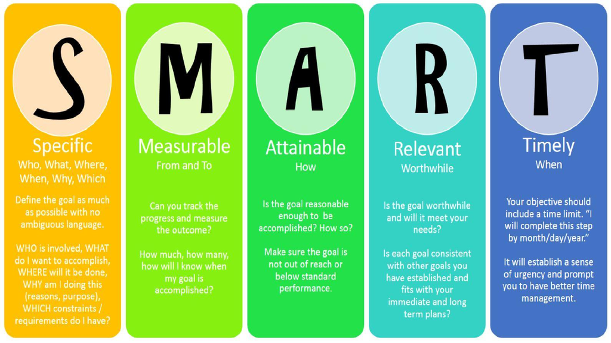

## Analyze: Matching Involvement to Strategy

- Identify if your offering is low or high involvement.
- Use emotional appeals for high-involvement campaigns (e.g. art, cars).
- Simplify decisions for low-involvement products with clear CTAs.
- Adjust content length and format to match decision-making complexity.
- Select appropriate messaging tone based on involvement level.

[figure not shown]

## Plan: Customer Journey Endgame

- Map customer journey from awareness to conversion.
- Highlight role of campaign landing pages in endgame.
- Study e-commerce platforms like Amazon for insights.
- Identify key touchpoints driving final purchase decisions.
- Design strategies to streamline journey to conversion.

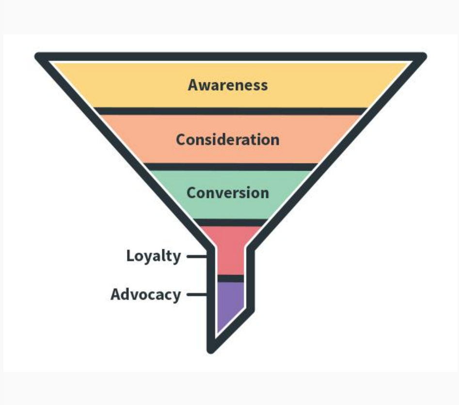

## Customer Journey: Awareness

- new businesses
- discovery
- knowledge
- memory
- top of mind
- display advertising

[figure not shown]

## Customer Journey: Consideration

- interest, engagement
- information search
- product comparison
- brand attitude
- high intention
- lead generation
- search engine marketing

[figure not shown]

## Customer Journey: Conversion

- action, decision
- product purchase
- cta button, call to action
- clicks, website traffic
- fill in lead forms
- online store interaction

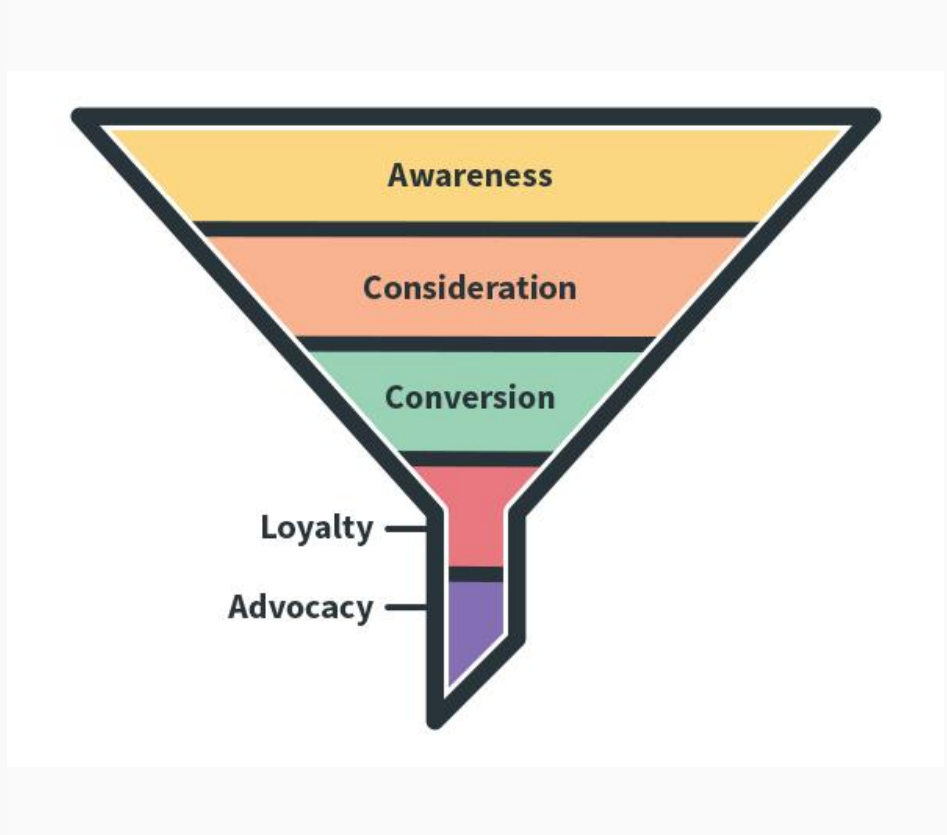

[video not shown]

## Plan: Aligning Journey with Brand

- Ensure each touchpoint reflects consistent brand messaging.
- Connect offline and online brand experiences.
- Design journey stages to support emotional and rational decision-making.
- Personalize experiences based on user behavior and history.
- Test user paths and refine them based on real behavior data.

[figure not shown]

## Plan: Designing Campaign Landing Site

- Craft a compelling hero section for instant engagement.
- Ensure responsive design for mobile and desktop users.
- Optimize for search engines to boost visibility.
- Include web forms for effective lead generation.
- Conduct A/B testing to refine site performance.

[figure not shown]

## Live demo: Google sites

- https://sites.google.com/u/0/new?pli=1&authuser=0
- https://webflow.com/made-in-webflow/business-landing-page

## Plan: Persuasive Landing Page Techniques

- Apply visual hierarchy to guide attention.
- Use testimonials or reviews to build trust.
- Create urgency with time-sensitive offers or CTAs.
- Reduce distractions with minimal navigation.
- Reinforce the offer’s value proposition at multiple points.

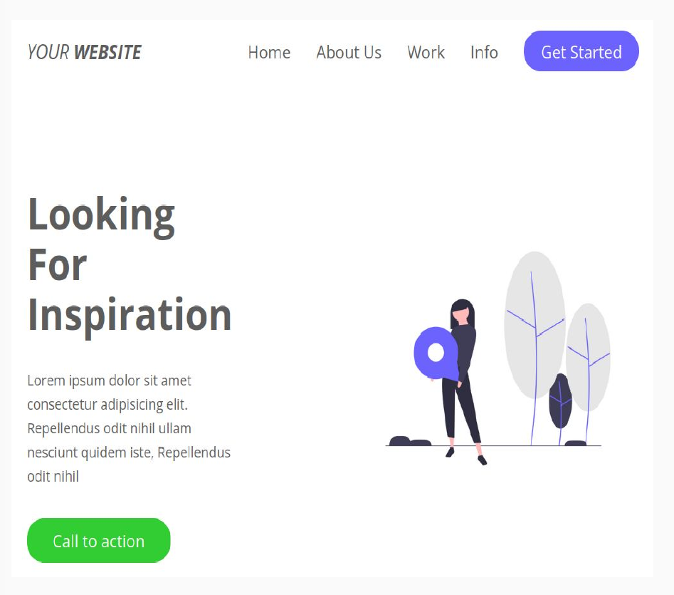

## Plan: Measurement Infrastructure

- Define KPIs before launch and configure tools accordingly.
- Use tags and triggers for granular event tracking.
- Create dashboards to monitor performance in real time.
- Integrate analytics with ad platforms for better attribution.
- Document your measurement plan for future optimization.

[figure not shown]

## Plan: Monitoring Campaign Landing Site

- Track conversion types like purchases and sign-ups.
- Use Google Analytics for detailed performance insights.
- Monitor web analytics measures like bounce rates.
- Set up real-time tracking for immediate feedback.
- Adjust tactics based on analytics-driven trends.

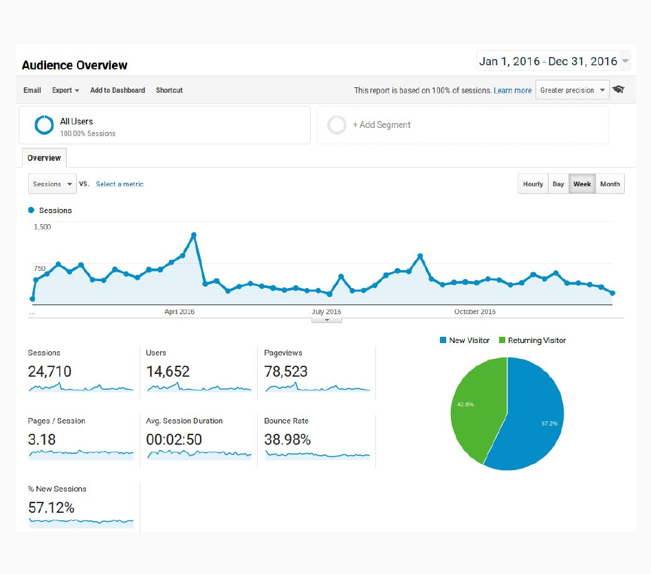

## Live demo: Google analytics

- [Google Merchandise Store](https://www.googlemerchandisestore.com/shop.axd/Home?utm_source=partners&utm_medium=affiliate&utm_campaign=data%20share%20article)
- [Google Analytics 4 property](https://analytics.google.com/analytics/index/demoaccount?appstate=/p213025502)
- [Google Analytics 4 property](https://analytics.google.com/analytics/web/?utm_source=demoaccount&utm_medium=demoaccount&utm_campaign=demoaccount#/p213025502/reports/intelligenthome?params=_u..nav%3Dmaui)

## Plan: Understanding Target Audience

- Segment audience using demographic data insights.
- Analyze personality traits to tailor messaging.
- Identify interests to create relevant campaign content.
- Study online behavior to predict digital preferences.
- Gather feedback to refine audience understanding.

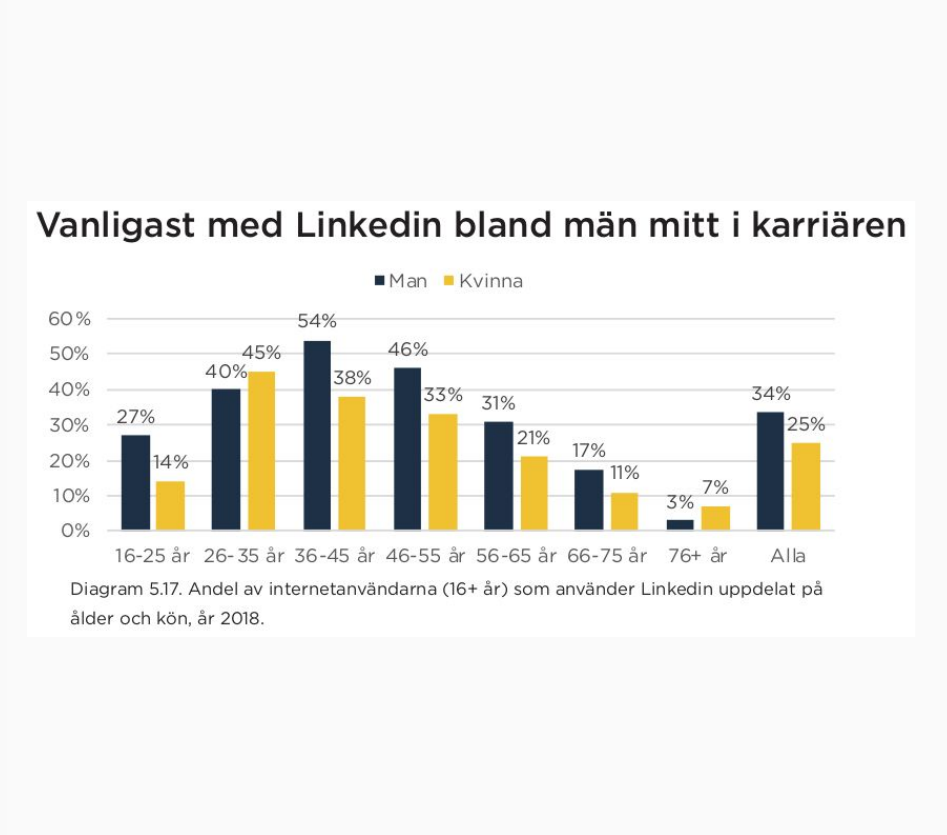

## Plan: Building Data-Driven Personas

- Use analytics, surveys, and CRM data to inform personas.
- Include goals, challenges, and preferred channels for each persona.
- Create scenario-based personas tied to specific campaigns.
- Update personas as more behavioral data becomes available.
- Align content and visuals with persona expectations.

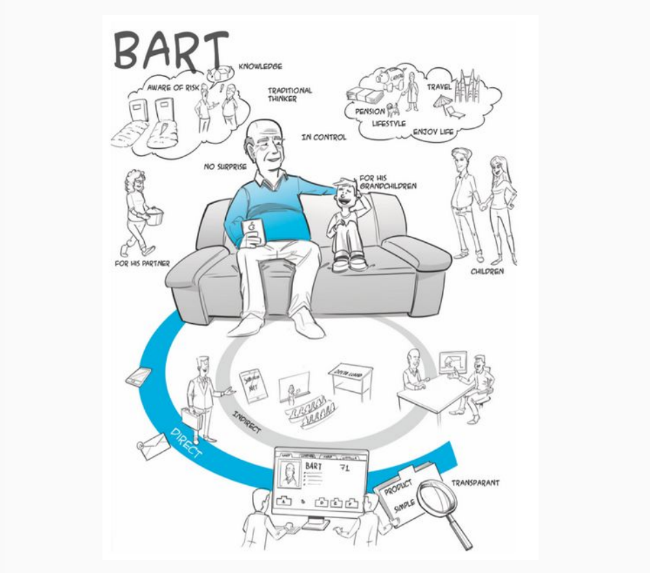

## Plan: Selecting Digital Channels

- Use display adverts for awareness campaign reach.
- Optimize consideration campaigns for lead generation.
- Target conversion campaigns to high-intent channels.
- Evaluate channel performance against campaign goals.
- Allocate resources to channels with strong ROI.

[figure not shown]

## Digital Channels

- content
  - websites, landing page
  - blogs, news media
- search
  - sem, seo
- social
  - interaction, engagement
- video
  - instructional, casual

[figure not shown]

## Plan: Channel Tactics for Each Funnel Stage

- Awareness: prioritize video and display for broad exposure.
- Consideration: use email, blogs, and influencers for deeper engagement.
- Conversion: rely on retargeting, search, and direct-response ads.
- Retention: focus on email and loyalty programs.
- Use analytics to see where users drop off and re-engage them.

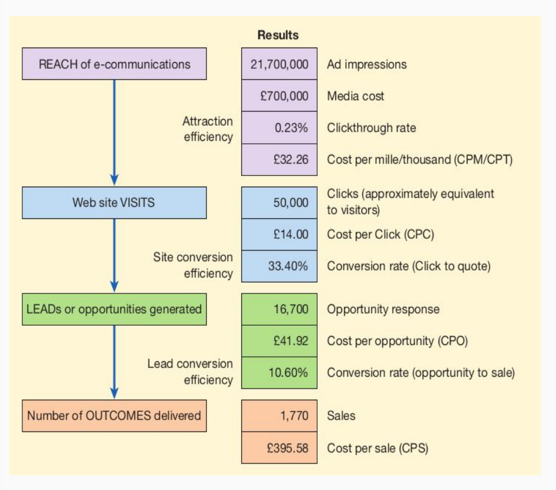

## References

[1]

D. Chaffey and F. Ellis-Chadwick, *Digital marketing*. Pearson uk, 2019.